# Revising APS 135

Tuesday 3, 2017

## While we're waiting

Start RStudio and open up a new R scipt. Add R code to load the **dplyr** and **ggplot2** packages, read in the STORMS.CSV file, and remind yourselfwhat kind of variables it contains, e.g.

```r
# clear the workspace (aka R's 'brain')
rm(list = ls())

# load and attach the packages we need
library("dplyr")
library("ggplot2")

# read the data in STORMS.CSV into R + call the result 'storms'
storms <- read.csv("STORMS.CSV")
# convert the data frame to a tibble
storms <- as_data_frame(storms)
# take a look at the data
glimpse(storms)
```

## The **dplyr** package

### Manipulating data

## The five key verbs

**dplyr** has five main "verbs", each of which corresponds to a function:

- `select`: Extract a subset of variables
- `filter`: Extract a subset of rows
- `arrange`: Reorder rows
- `mutate`: Construct new variables
- `summarise`: Calculate information about groups

(+ a few other important functions that we need too, e.g. `slice`, `rename`, and **most important of all**, `group_by`)

**We can classify the verbs according to what they work on:**

- observations (rows): `filter` & `slice` & `arrange`
- variables (columns): `select` & `rename` & `mutate`

(This classification only works if your data are **tidy**)

## Using `filter`

Use **relational operators** to compare the elements of vectors:

- `x < y`: is x less than y?
- `x > y`: is x greater than y?
- `x <= y`: is x less than or equal to y?
- `x >= y`: is x greater than or equal to y?
- `x == y`: is x equal to y?
- `x != y`: is x not equal to y?

Use **logical operators** to combine comparisons:

- `x & y`: are both x AND y TRUE?
- `x | y`: is x OR y true?

## Using `filter`

Use `filter` to select a subset of rows for further analysis based on the result(s) of one or more comparisons. Using `filter` looks like this:

```r
filter(data, <expression>)
```

**Arguments**

- `data`: the name of a data frame or tibble object
- `<expression>`: logical comparison involving variables in `data`

**Comments**

The `<expression>` typically uses a combination of **relational** (e.g. `<` and `==`) and (sometimes) **logical** (e.g. `&` and `|`) operators

## Exercise

**Subsetting observations on more than one variable**

Use the `filter` function on the `storms` data set to select the rows containing just the observations associated with EITHER a 'Hurricane' OR a 'Tropical Storm'. Print the result to the Console.

```r
filter(storms, type == "Hurricane" | type == "Tropical Storm")
```

```
##           name year month day hour  lat  long pressure wind           type
## 1      Allison 1995     6   3   12 19.3 -85.7     1003   35 Tropical Storm
## 2      Allison 1995     6   3   18 20.6 -85.8     1001   40 Tropical Storm
## 3      Allison 1995     6   4    0 22.0 -86.0      997   50 Tropical Storm
## 4      Allison 1995     6   4    6 23.3 -86.3      995   60 Tropical Storm
## 5      Allison 1995     6   4   12 24.7 -86.2      987   65      Hurricane
## 6      Allison 1995     6   4   18 26.2 -86.2      988   65      Hurricane
## 7      Allison 1995     6   5    0 27.6 -86.1      988   65      Hurricane
## 8      Allison 1995     6   5    6 28.5 -85.6      990   60 Tropical Storm
## 9      Allison 1995     6   5   12 29.6 -84.7      990   60 Tropical Storm
## 10     Allison 1995     6   5   18 30.7 -83.8      993   45 Tropical Storm
## 11       Barry 1995     7   7    6 31.6 -71.0     1007   35 Tropical Storm
## 12       Barry 1995     7   7   12 32.2 -70.6     1004   40 Tropical Storm
## 13       Barry 1995     7   7   18 33.2 -70.2     1001   60 Tropical Storm
## 14       Barry 1995     7   8    0 34.0 -69.6      997   60 Tropical Storm
```

[output cut: 3631 more lines]

## Using `select`

We use `select` to to extract a subset of variables for further analysis. Using `select` looks like this:

```r
select(data, Variable1, Variable2, ...)
```

**Arguments**

- `data`: the name of a data frame or tibble object
- `VariableX`: the names of one or more variables in `data`

## Exercise

Use the `select` function on the `storms` data set to make a new data set containing only `name`, `year` and `pressure`. Assign a name to the result (i.e. use `<-`) and then check that it contains the right variables using the `glimpse` function.

```r
simple_storms <- select(storms, name, year, pressure)
glimpse(simple_storms)
```

```
## Observations: 2,747
## Variables: 3
## $ name     <fctr> Allison, Allison, Allison, Allison, Allison, Allison...
## $ year     <int> 1995, 1995, 1995, 1995, 1995, 1995, 1995, 1995, 1995,...
## $ pressure <int> 1005, 1004, 1003, 1001, 997, 995, 987, 988, 988, 990,...
```

## Using `mutate`

Use `mutate` to **add derived variables**. This is how we use `mutate`:

```r
mutate(data, NewVar = <expression>, ...)
```

**Arguments**

- `data`: the name of a data frame or tibble object
- `NewVar`: name of a new variable to create
- `<expression>`: an expression that references variables in `data`

**Comments**

- The `<expression>` that appears on the right hand side of the `=` can be any valid R expression that uses variables in `data`.
- You can use more than one `NewVar = <expression>` at a time if you need to construct several new variables.

## Exercise

**Making a new variable**

The sea level pressure of every observation is measured in millibar. Use the `mutate` function on the `storms` data set to make a new variable (inside `storms`) that is the sea level pressure in Pascal. Call the new variable `pressure_Pa`.

Hint: 1 mbar = 100 Pa

```r
mutate(storms, pressure_Pa = 100 * pressure)
```

```
##           name year month day hour  lat   long pressure wind
## 1      Allison 1995     6   3    0 17.4  -84.3     1005   30
## 2      Allison 1995     6   3    6 18.3  -84.9     1004   30
## 3      Allison 1995     6   3   12 19.3  -85.7     1003   35
## 4      Allison 1995     6   3   18 20.6  -85.8     1001   40
## 5      Allison 1995     6   4    0 22.0  -86.0      997   50
## 6      Allison 1995     6   4    6 23.3  -86.3      995   60
## 7      Allison 1995     6   4   12 24.7  -86.2      987   65
## 8      Allison 1995     6   4   18 26.2  -86.2      988   65
## 9      Allison 1995     6   5    0 27.6  -86.1      988   65
## 10     Allison 1995     6   5    6 28.5  -85.6      990   60
## 11     Allison 1995     6   5   12 29.6  -84.7      990   60
## 12     Allison 1995     6   5   18 30.7  -83.8      993   45
## 13     Allison 1995     6   6    0 31.8  -82.8      993   30
## 14     Allison 1995     6   6    6 32.7  -81.5      994   35
```

[output cut: 5481 more lines]

## The **dplyr** package

### Piping operations and summarising data

## Using the 'pipe' `%>%`

The **dplyr** package imports a special operator, called 'the pipe'. It looks like this: `%>%`. This allows us to chain together a sequence of operations, reading from left to right and top to bottom. For example, take a look at this sequence of calculations:

```r
x <- 10
x <- sqrt(x)
round(x, 2)
```

```
## [1] 3.16
```

The piped version looks like this

```r
10 %>% sqrt() %>% round(2)
```

```
## [1] 3.16
```

## Exercise

**Making a new variable**

See if you can use the `%>%` to construct a pipeline that filters, selects, and then mutates the `storms` data, using the same criteria as were used in each of the last three exercises.

```r
storms %>%
  filter(type == "Hurricane" | type == "Tropical Storm") %>%
  select(name, year, pressure) %>%
  mutate(pressure_Pa = 100 * pressure)
```

```
##           name year pressure pressure_Pa
## 1      Allison 1995     1003      100300
## 2      Allison 1995     1001      100100
## 3      Allison 1995      997       99700
## 4      Allison 1995      995       99500
## 5      Allison 1995      987       98700
## 6      Allison 1995      988       98800
## 7      Allison 1995      988       98800
## 8      Allison 1995      990       99000
## 9      Allison 1995      990       99000
## 10     Allison 1995      993       99300
## 11       Barry 1995     1007      100700
## 12       Barry 1995     1004      100400
## 13       Barry 1995     1001      100100
## 14       Barry 1995      997       99700
```

[output cut: 1808 more lines]

## Warning!

Remember that if you want to actually use the result of a piped set of operations, you have to assign a name to the result, e.g.

```r
processed_storms <-
  storms %>%
  filter(type == "Hurricane" | type == "Hurricane") %>%
  select(name, year, pressure) %>%
  mutate(pressure_Pa = 100 * pressure)
```

## Using the `summarise` function

We use summarise to **calculate summaries of variables**. This is how we use `summarise`:

```r
summarise(data, SummaryVar = <expression>, ...)
```

**Arguments**

- `data`: the name of a data frame or tibble object
- `SummaryVar`: name of your summary variable
- `<expression>`: an expression that references variables in `data`

**Comments**

- The `<expression>` that appears on the right hand side of the `=` can be any valid R expression that uses variables in `data`. However, `<expression>` **must return a single value** (e.g. `mean()`, `var()`, `sd()`, `n()` are all fine).
- Although `summarise` looks a lot like `mutate`, it is designed to construct a completely new, much smaller, data set containing summaries of one or more variables.
- You may use more than one `SummaryVar = <expression>` at a time (separated by `,`) if you need to construct several summaries.

## Using the `group_by` function

Use `group_by` to add grouping information to a tibble or data frame. This is how we use `group_by`:

```r
group_by(data, GroupVar1, GroupVar2, ...)
```

**Arguments**

- `data`: the name of a data frame or tibble object
- `GroupVar`: name of grouping variable(s)

**Comments**

- The `group_by` function does not do anything more than add grouping information to the input. It is only useful when used with another function (e.g `summarise`).
- Using `group_by` with `summarise` enables us to calculate numerical summaries on a *per group* basis.

## Exercise

You're going to use `group_by` and `summarise` together, along with the pipe (`%>%`) in this exercise. Use the `group_by` and `summarise` functions on the `storms` data set to calculate the minimum and maximum wind speed associated with each month. Call the summary variables `min_speed` and `max_speed`.

```r
storms %>%
  group_by(month) %>%
  summarise(min_speed = min(wind), max_speed = max(wind))
```

```
## # A tibble: 7 × 3
##   month min_speed max_speed
##   <int>     <int>     <int>
## 1     6        25        65
## 2     7        20       100
## 3     8        20       125
## 4     9        15       135
## 5    10        20       155
## 6    11        20       135
## 7    12        50        75
```

## Overview of **ggplot2**

### The grammar of graphics

## Key concepts

You need to wrap your head around a few ideas to start using **ggplot2** effectively:

- **layers**: We build ggplot2 objects by adding one or more layers together. We can do this in a stepwise way, only plotting the object when we are ready. Each layer needs things like data, aesthetics, geometric objects, etc
- **aesthetics**: The word aesthetics refers to **the information** in a plot. For example, the variables associated with: the x and y axes, point colours, line types, etc. We specify this using the `aes` function.
- **geometric objects**: Geometric objects ("geoms") determine how the information is displayed. For example, will it be a scatter plot or a bar plot? We can specify geoms by adding a layer via functions beginning with `geom_`.

We build up a plot by combining different functions using the `+` operator. This has nothing to do with numeric addition!

## Example: Scatter plots

**Quick reminder of how all this works**:

We don't have to build a plot object up in separate steps and then explicitly "print"" it to the Console. If we just want to make the plot in one go we can do it like this:

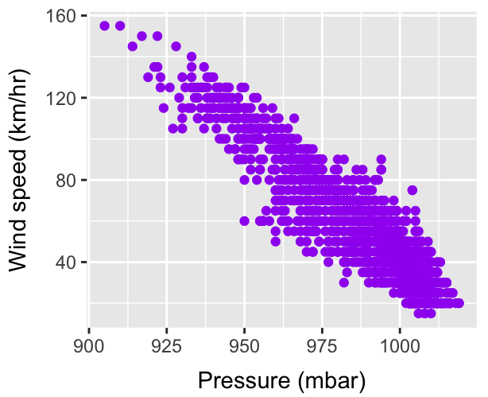

```r
ggplot(storms, aes(x = pressure, y = wind)) +
  geom_point(colour = "purple") +
  labs(x = "Pressure (mbar)", y = "Wind speed (km/hr)")
```

## Exercise

**Customising your plot**

Repeat the last example (a scatter plot of wind speed vs pressure), but now try to customise the point colours, size, and transparency.

Hint: Try `?geom_point` if you can't remember how to do this, looking at the **Aesthetics** section. An example of suitable output is given below.

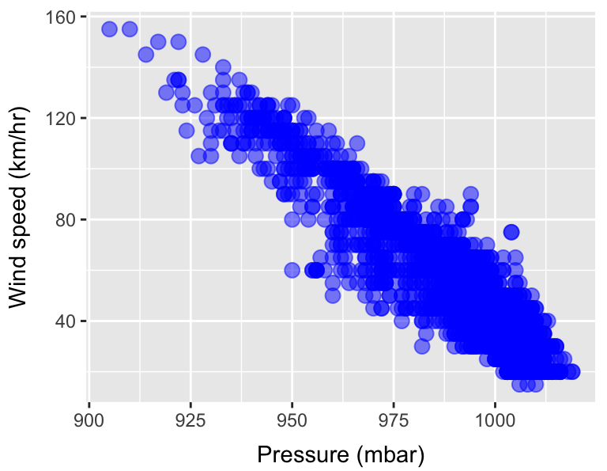

## Answer

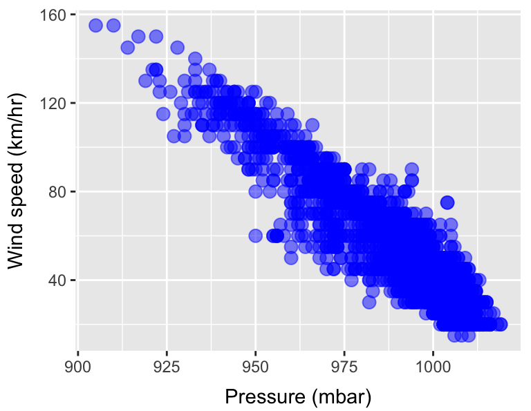

```r
ggplot(storms, aes(x = pressure, y = wind)) +
  geom_point(colour = "blue", size = 3, alpha = 0.5) +
  labs(x = "Pressure (mbar)", y = "Wind speed (km/hr)")
```

## Exercise

**Customising your plot**

Repeat the last example (a scatter plot of wind speed vs pressure), but now make the point colour depend upon storm type (i.e. the `type` variable). This requires that you set up a new mapping between a variable and a suitable 'aesthetic'.

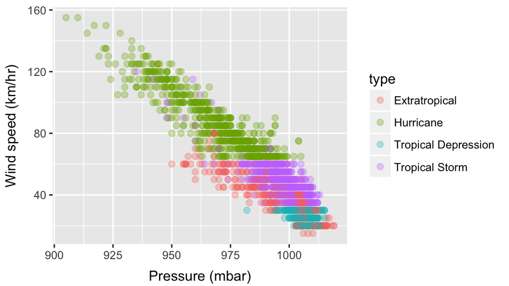

## Answer

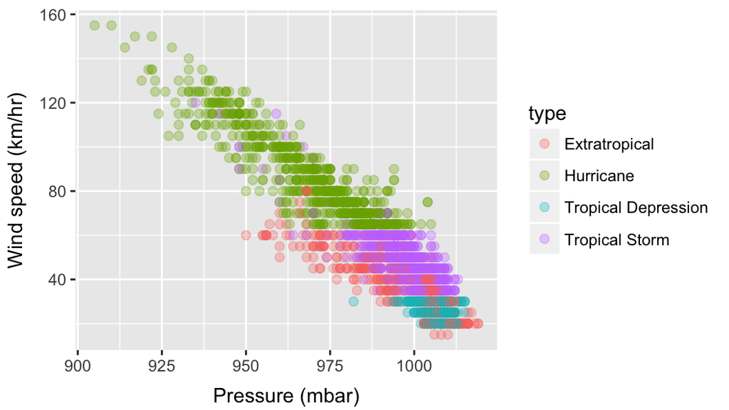

```r
ggplot(storms, aes(x = pressure, y = wind, colour = type)) +
  geom_point(size = 2, alpha = 0.3) +
  labs(x = "Pressure (mbar)", y = "Wind speed (km/hr)")
```

## Exercise

**Aesthetic mappings vs. arguments to `geom_`**

We can set something like "colour" in two places: the aesthetic mapping (`aes`) or via an argument to a geom (`geom_`). Remember what happens if we set the colour in both places at once? Experiment with the last example to make sure you understand which one—the aesthetic mapping geom argument—has precedence?

## Answer

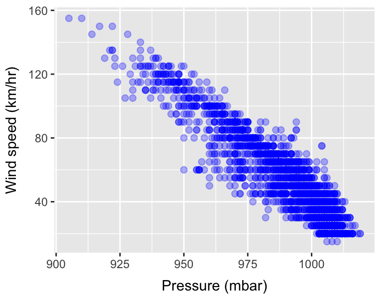

```r
ggplot(storms, aes(x = pressure, y = wind, colour = type)) +
  geom_point(colour = "blue", size = 2, alpha = 0.3) +
  labs(x = "Pressure (mbar)", y = "Wind speed (km/hr)")
```

## What are histograms and dot plots?

We use histograms and dot plots to understand the **distribution** of a variable. They summarise the number of observations occurring in a contiguous series of bins. Use `geom_histogram` to construct a histogram and `geom_dotplot`. Here's an example:

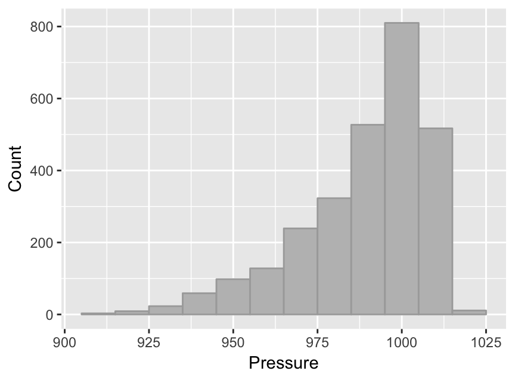

See if you can make that plot…

## Answer

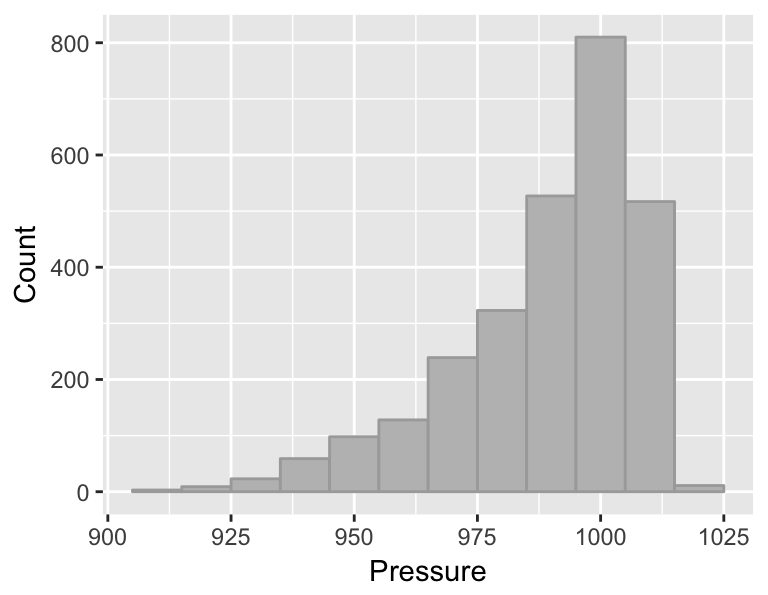

```r
ggplot(storms, aes(x = pressure)) +
  geom_histogram(colour = "darkgrey", fill = "grey", binwidth=10) +
  labs(x = "Pressure", y = "Count")
```

## Using **dplyr** and **ggplot2** together

Dot plots are better than histograms for summarising the distribution of a variable in a small sample. You will see a lot of dot plots this year. See if you can produce one that summarises the distribution of wind speeds associated with storm 'Keith'. To do this, you will need to use **dplyr** to get the right set of observations.

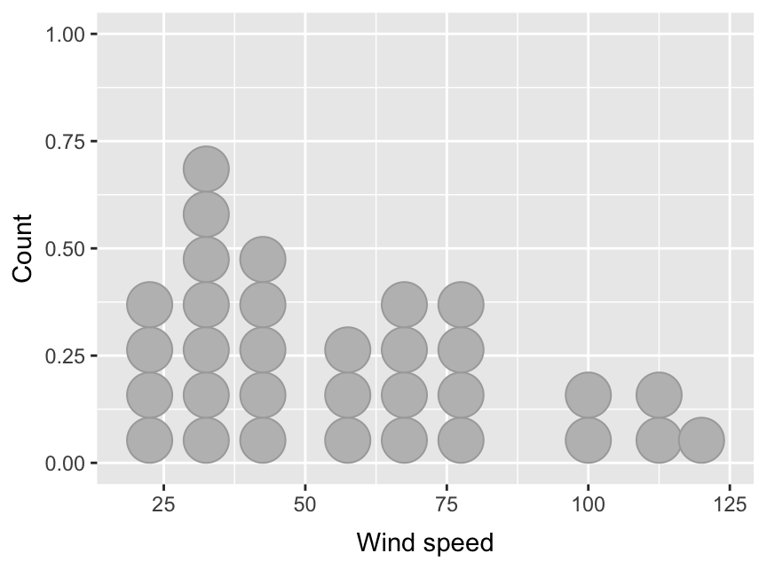

## Answer

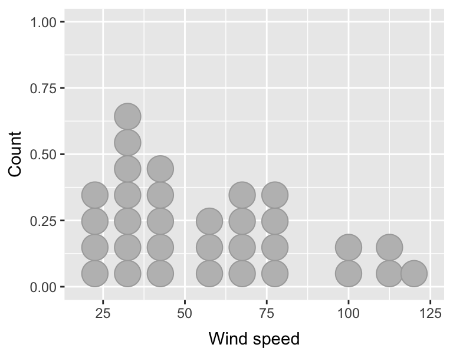

```r
storms %>%
  filter(name == "Keith") %>%
  ggplot(aes(x = wind)) +
    geom_dotplot(colour = "darkgrey", fill = "grey", binwidth = 8) +
    labs(x = "Wind speed", y = "Count")
```

## Plotting summary statistics (bar plots)

If we want to compare a summary statistic (e.g. the mean) across groups we need to walk through a two step process:

1. First use functions like `group_by` and `summarise` function from the **dplyr** package to calculate the mean for each group.
2. Then use **ggplot2** with the new data set of means to plot the summary statistic. We usually use either a bar plot (`geom_col`) or a points plot (`geom_point`) to do this.

## Exercise

**Making a barplot of means**

Working with the `storms` dataset, construct a bar plot to summarises the mean wind speed (`wind`) associated with storms in each year (`year`). This is a two step process. First use **dplyr** to calculate the mean wind speed for each year, then use **ggplot2** (`geom_col`) with the summarised data set to produce the bar plot.

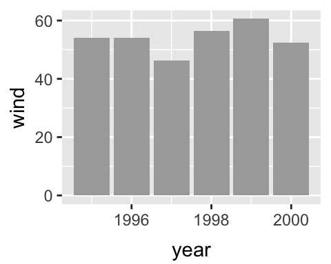

## Answer

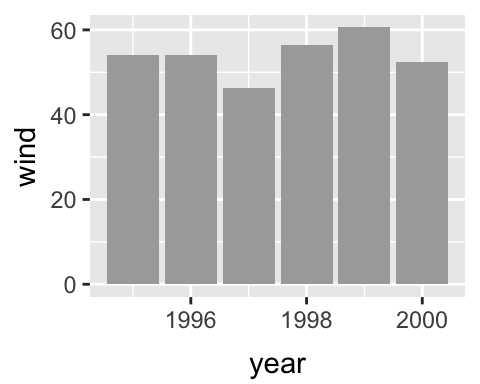

```r
# step 1 - use dplyr to calculate the means
wind.means <-
  storms %>% group_by(year) %>%
  summarise(wind = mean(wind))
# step 2 - make the plot
ggplot(wind.means, aes(x = year, y = wind)) +
  geom_col(fill="darkgrey")
```

## Exercise (Harder)

**Making a barplot of means and standard errors**

Working with the `storms` dataset, construct a bar plot to summarises the mean **and standard error** of wind speed (`wind`) associated with storms in each year (`year`). Again, this is a two step process. First use **dplyr** to calculate the mean wind speed for each year, then use **ggplot2** (`geom_col` and `geom_errorbar`) with the summarised data set to produce the bar plot. N.B. – you need to add two layers to get both pieces of information onto the figure.

\[ \text{Standard Error} = \frac{\text{Standard Deviation}}{\sqrt(Sample Size)} \]

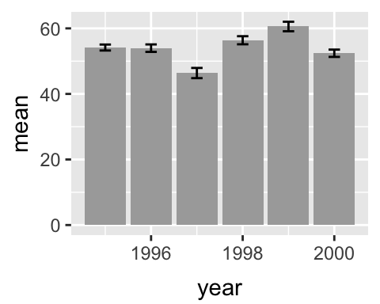

## Answer

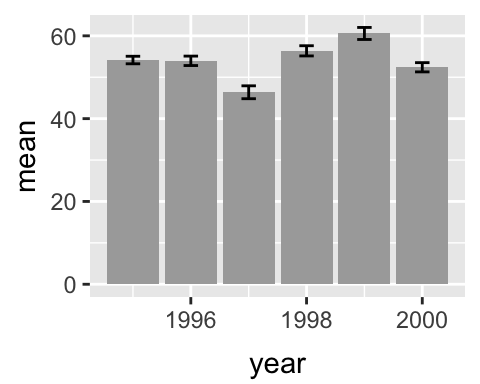

```r
# step 1
wind.means <-
  storms %>% group_by(year) %>%
  summarise(mean = mean(wind),
            se = sd(wind)/sqrt(n()))
# step 2
ggplot(wind.means,
       aes(x = year, y = mean, ymin = mean-se, ymax = mean+se)) +
  geom_col(fill="darkgrey") +
  geom_errorbar(width = 0.25)
```

## Wrap up

## Miscellaneous 'stuff'

- R does not change things 'in place'. You have to use assignment `<-` ('gets') to store copies of objects…
- Scientific notation in R looks like this: `1e-16`. That is R-speak for \(1.0 \times 10^{-16}\), i.e. a very small number.
- Don't forget the basics, e.g. `mean()`, `var()`, `sd()`, `n()`
- Keyboard shortcuts are useful. You should learn a few. I really like 'Alt-Underscore' and 'Ctrl-Shift-M'.

## Two tips for success

1. **Keep your scripts organised and well-commented** If you don't, you will make a lot of mistakes, you will find it harder to revise, and next year, you won't have a clue how to analyse your own data.
2. **Do required reading each week, take good notes, and ask questions** It may be tempting to skip the reading each week. Don't do this. At the very least, work through it quickly, noting anything that is confusing you.